# Exam 1

## Exam 1

#### Question

1. La tabla muestra el registro semanal que lleva una persona de los gastos relacionados con su motocicleta.

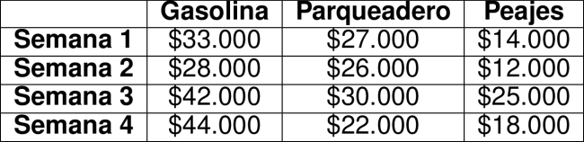

   Si la persona quiere identificar qué categoría de gasto representa la mayor proporción del presupuesto total, ¿cuál de las siguientes gráficas le permite hacer esto directamente?

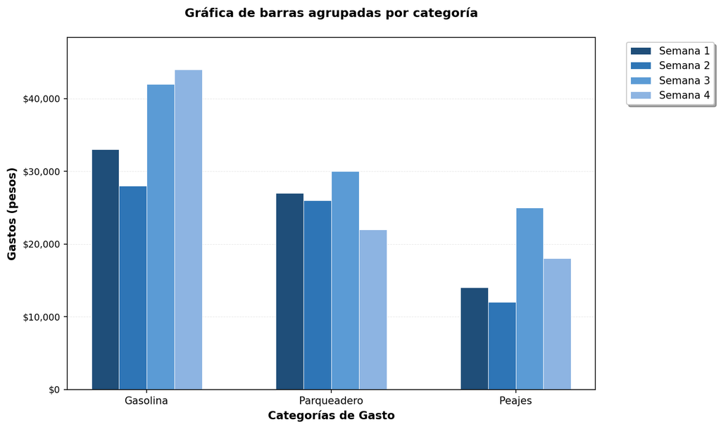

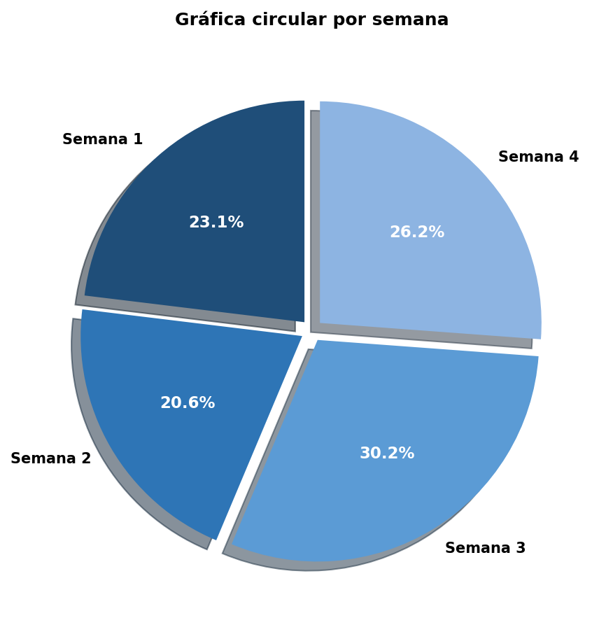

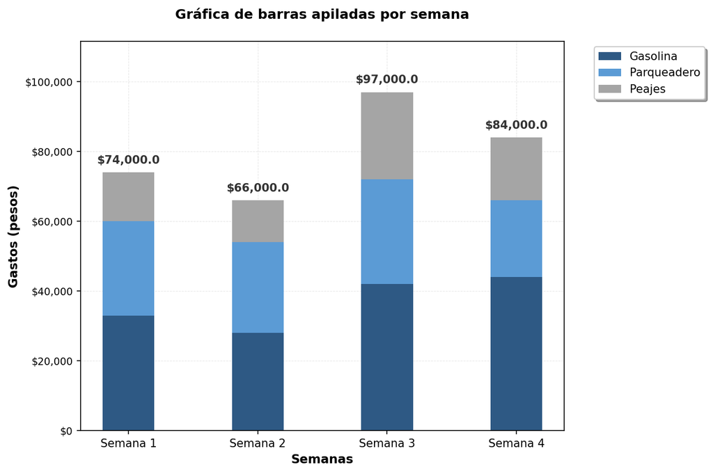

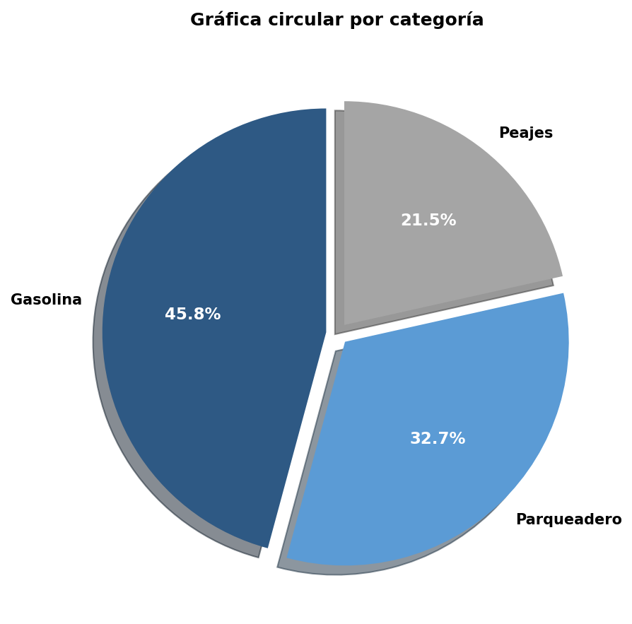

#### Solution

   Para resolver este problema, necesitamos identificar qué tipo de gráfica permite identificar directamente **qué categoría representa la mayor proporción del presupuesto total**.

### Análisis de los datos

   Primero, calculemos los gastos totales por categoría y sus proporciones:
   - **Gasolina:** $147.000 = 45.8% del total
   - **Parqueadero:** $105.000 = 32.7% del total
   - **Peajes:** $69.000 = 21.5% del total

   **Total general:** $321.000

   Como podemos observar, **Gasolina** representa la mayor proporción del presupuesto total.

### Análisis de cada opción

   **Gráfica circular por categoría:**
   - Muestra la proporción de cada tipo de gasto en el total general
   - Los porcentajes indican claramente qué categoría representa la mayor proporción del presupuesto
   - Permite identificar directamente la categoría dominante sin necesidad de cálculos adicionales
   - **Esta es la respuesta correcta**

   **Gráfica de barras apiladas por semana:**
   - Cada barra representa una semana
   - La altura total de cada barra muestra el gasto total de esa semana
   - NO permite identificar directamente qué categoría representa la mayor proporción

   **Gráfica circular por semana:**
   - Muestra la proporción de gastos de cada semana respecto al total del mes
   - NO permite identificar qué categoría representa la mayor proporción del presupuesto

   **Gráfica de barras agrupadas por categoría:**
   - Agrupa las barras por tipo de gasto (gasolina, parqueadero, peajes)
   - Permite ver gastos por categoría pero separados por semana
   - Requiere sumar mentalmente las barras de cada categoría para identificar la proporción dominante

### Conclusión

   La **Opción “gráfica circular por categoría”** es la única que permite identificar directamente qué categoría representa la mayor proporción del presupuesto total, ya que muestra claramente los porcentajes de cada tipo de gasto respecto al total general, facilitando la identificación inmediata de la categoría dominante.
   1. Falso
   2. Falso
   3. Falso
   4. Verdadero